# Dimensionality reduction techniques

02 Dec 2018

# Dimensionality reduction techniques (Week 5)

## Principle Components Analysis (PCA)

### Read Data

```r
library("readxl")
library("ggplot2")
library("data.table")
library("dplyr")
library("stringr")
library("tidyverse")
library("GGally")
library("ggplot2")
library("MASS")
library("corrplot")
library("plotly")
library("purrr")
library("devtools")
library("ggbiplot")
library("gridExtra")
library("grid")
library("lattice")
library("FactoMineR")

analysis.data <- read.table("~/Documents/GitHub/IODS-project/data/humans2.txt",
                    header=TRUE)
```

### Description of data

```r
glimpse(analysis.data)
```

```
## Observations: 155
## Variables: 8
## $ Life.expectancy   <dbl> 81.6, 82.4, 83.0, 80.2, 81.6, 80.9, 80.9, 79...
## $ Exp.school.years  <dbl> 17.5, 20.2, 15.8, 18.7, 17.9, 16.5, 18.6, 16...
## $ GNIncome          <int> 64992, 42261, 56431, 44025, 45435, 43919, 39...
## $ Mat.Mort.Rate     <int> 4, 6, 6, 5, 6, 7, 9, 28, 11, 8, 6, 4, 8, 4, ...
## $ Adol.Birth.Rate   <dbl> 7.8, 12.1, 1.9, 5.1, 6.2, 3.8, 8.2, 31.0, 14...
## $ Rep.Parliament... <dbl> 39.6, 30.5, 28.5, 38.0, 36.9, 36.9, 19.9, 19...
## $ Edu.F2M           <dbl> 1.0072389, 0.9968288, 0.9834369, 0.9886128, ...
## $ Lab.F2M           <dbl> 0.8908297, 0.8189415, 0.8251001, 0.8840361, ...
```

#### Rep.Parliament(%) = Percetange of female representatives in parliament

#### Edu.F2M = FSec.edu/MSec.edu

#### Lab.F2M = FLab.Rate/MLab.Rate

### Explore distributions of variables and their relationships

```r
# General summary of the dataset
summary(analysis.data)
```

```
##  Life.expectancy Exp.school.years    GNIncome      Mat.Mort.Rate
##  Min.   :49.00   Min.   : 5.40    Min.   :   581   Min.   :   1.0
##  1st Qu.:66.30   1st Qu.:11.25    1st Qu.:  4198   1st Qu.:  11.5
##  Median :74.20   Median :13.50    Median : 12040   Median :  49.0
##  Mean   :71.65   Mean   :13.18    Mean   : 17628   Mean   : 149.1
##  3rd Qu.:77.25   3rd Qu.:15.20    3rd Qu.: 24512   3rd Qu.: 190.0
##  Max.   :83.50   Max.   :20.20    Max.   :123124   Max.   :1100.0
##  Adol.Birth.Rate  Rep.Parliament...    Edu.F2M          Lab.F2M
##  Min.   :  0.60   Min.   : 0.00     Min.   :0.1717   Min.   :0.1857
##  1st Qu.: 12.65   1st Qu.:12.40     1st Qu.:0.7264   1st Qu.:0.5984
##  Median : 33.60   Median :19.30     Median :0.9375   Median :0.7535
##  Mean   : 47.16   Mean   :20.91     Mean   :0.8529   Mean   :0.7074
##  3rd Qu.: 71.95   3rd Qu.:27.95     3rd Qu.:0.9968   3rd Qu.:0.8535
##  Max.   :204.80   Max.   :57.50     Max.   :1.4967   Max.   :1.0380
```

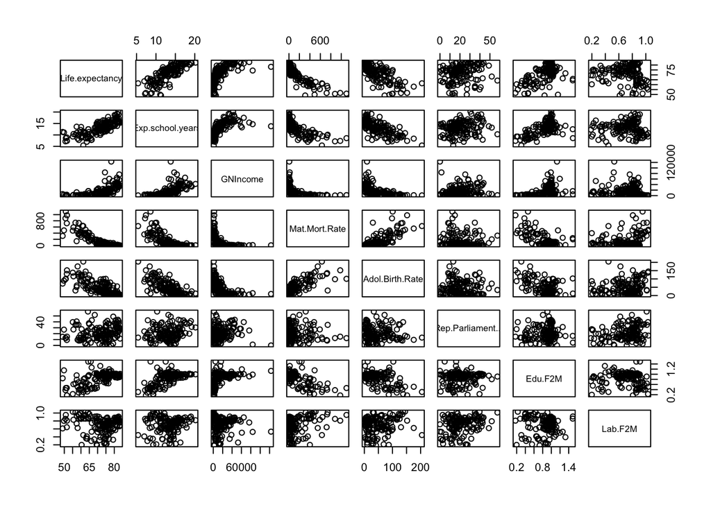

```r
# Matrix of the variables
pairs(analysis.data)
```

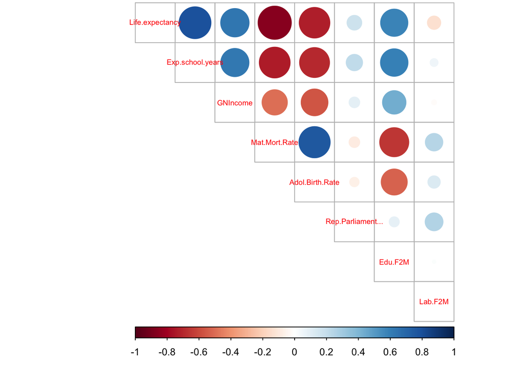

```r
# Correlation matrix
cor_matrix <- cor(analysis.data) %>% round(2)
corrplot(cor_matrix, method = "circle", type = "upper",
cl.pos = "b", tl.pos = "d", tl.cex = 0.6)
```

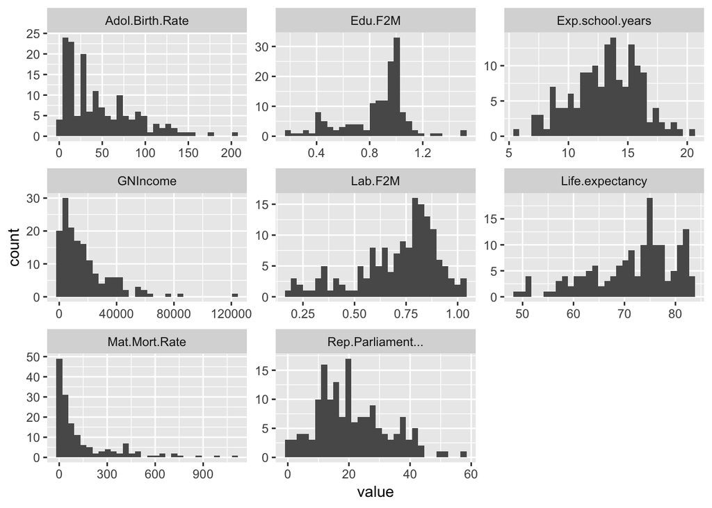

```r
# Visualise distributions of the variables
analysis.data %>% keep(is.numeric) %>%
  gather() %>%
  ggplot(aes(value)) + facet_wrap(~ key, scales = "free") + geom_histogram()
```

### Principal component analysis (with the SVD method)

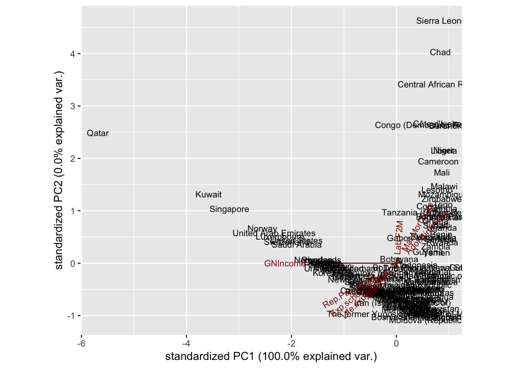

```r
# PCA
pca_human <- prcomp(analysis.data)

# Draw a biplot of the principal component representation and the original variables
# Using the ggbiplot package instead of normal biplot
ggbiplot(pca_human,  choices=c(1,2), ellipse = TRUE, labels =  rownames(analysis.data)) +
  scale_color_discrete(name = '') +
  theme(legend.direction = 'horizontal', legend.position = 'top')
```

### Principal component analysis (with the SVD method) WITH Standardized variables

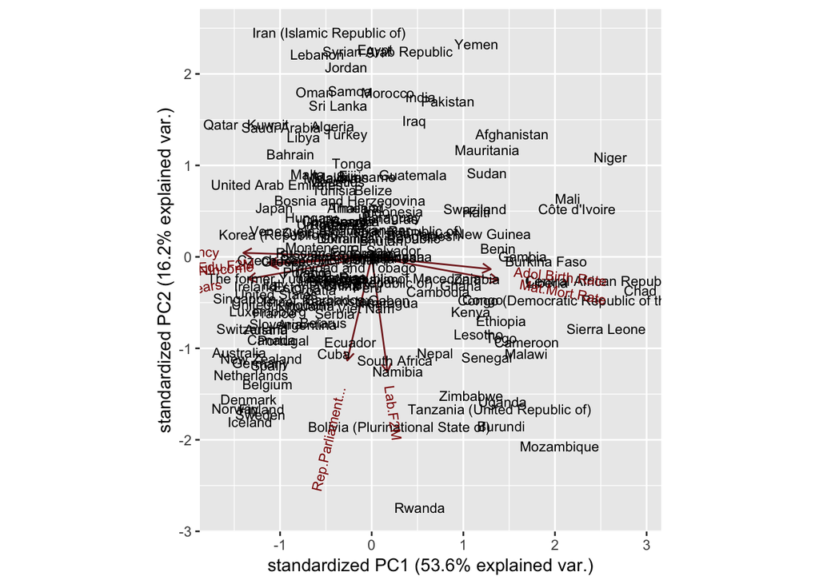

```r
# Standardize dataset
human_std <- scale(analysis.data)

# PCA
pca_human_std <- prcomp(human_std)

# Draw a biplot of the principal component representation and the original variables
# Using the ggbiplot package instead of normal biplot
ggbiplot(pca_human_std,  choices=c(1,2), ellipse = TRUE, labels =  rownames(analysis.data)) +
  scale_color_discrete(name = '') +
  theme(legend.direction = 'horizontal', legend.position = 'top')
```

### Let’s look at what the various PC componenets explain in both above

### First PCA with original dataset

```r
pca_human
```

```
## Standard deviations (1, .., p=8):
## [1] 1.854416e+04 1.855219e+02 2.518701e+01 1.145441e+01 3.766241e+00
## [6] 1.565912e+00 1.912052e-01 1.591112e-01
##
## Rotation (n x k) = (8 x 8):
##                             PC1           PC2           PC3           PC4
## Life.expectancy   -2.815823e-04 -0.0283150248 -1.294971e-02  6.752684e-02
## Exp.school.years  -9.562910e-05 -0.0075529759 -1.427664e-02  3.313505e-02
## GNIncome          -9.999832e-01  0.0057723054  5.156742e-04 -4.932889e-05
## Mat.Mort.Rate      5.655734e-03  0.9916320120 -1.260302e-01  6.100534e-03
## Adol.Birth.Rate    1.233961e-03  0.1255502723  9.918113e-01 -5.301595e-03
## Rep.Parliament... -5.526460e-05 -0.0032317269  7.398331e-03  9.971232e-01
## Edu.F2M           -5.607472e-06 -0.0006713951  3.412027e-05  2.736326e-04
## Lab.F2M            2.331945e-07  0.0002819357 -5.302884e-04  4.692578e-03
##                             PC5           PC6           PC7           PC8
## Life.expectancy    0.9865644425  1.453515e-01 -5.380452e-03  2.281723e-03
## Exp.school.years   0.1431180282 -9.882477e-01  3.826887e-02  7.776451e-03
## GNIncome          -0.0001135863  2.711698e-05  8.075191e-07 -1.176762e-06
## Mat.Mort.Rate      0.0266373214 -1.695203e-03 -1.355518e-04  8.371934e-04
## Adol.Birth.Rate    0.0188618600 -1.273198e-02  8.641234e-05 -1.707885e-04
## Rep.Parliament... -0.0716401914  2.309896e-02  2.642548e-03  2.680113e-03
## Edu.F2M           -0.0022935252 -2.180183e-02 -6.998623e-01  7.139410e-01
## Lab.F2M            0.0022190154 -3.264423e-02 -7.132267e-01 -7.001533e-01
```

```r
summary(pca_human)
```

```
## Importance of components:
##                              PC1      PC2   PC3   PC4   PC5   PC6    PC7
## Standard deviation     1.854e+04 185.5219 25.19 11.45 3.766 1.566 0.1912
## Proportion of Variance 9.999e-01   0.0001  0.00  0.00 0.000 0.000 0.0000
## Cumulative Proportion  9.999e-01   1.0000  1.00  1.00 1.000 1.000 1.0000
##                           PC8
## Standard deviation     0.1591
## Proportion of Variance 0.0000
## Cumulative Proportion  1.0000
```

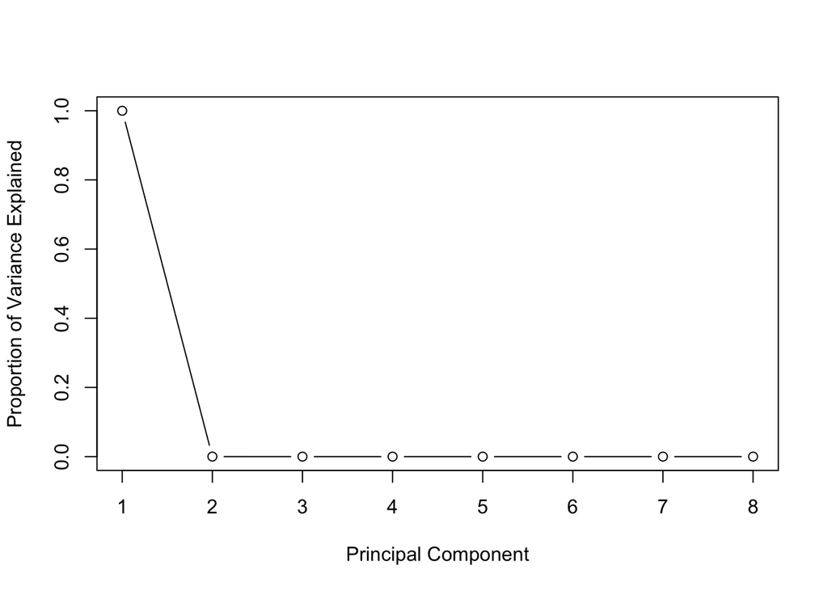

```r
# Compute standard deviation of each principal component
std_dev <- pca_human$sdev

# Compute variance
pr_var <- std_dev^2

# Proportion of variance explained
prop_varex <- pr_var/sum(pr_var)

# Scree plot
plot(prop_varex, xlab = "Principal Component",
             ylab = "Proportion of Variance Explained",
             type = "b")
```

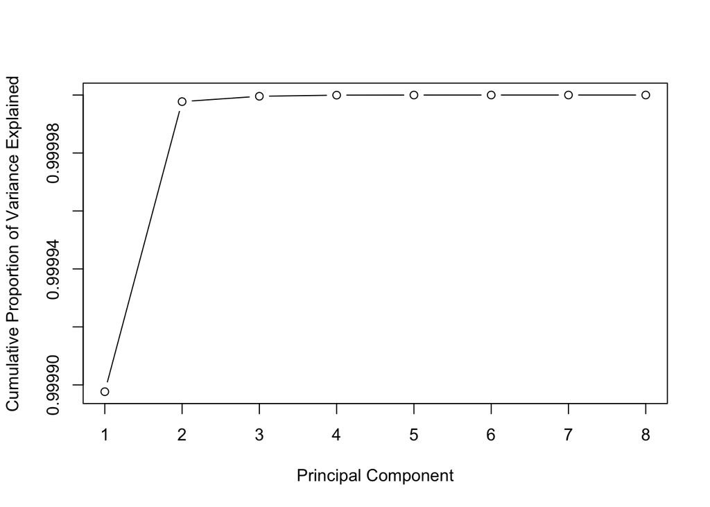

```r
# Cumulative scree plot
plot(cumsum(prop_varex), xlab = "Principal Component",
              ylab = "Cumulative Proportion of Variance Explained",
              type = "b")
```

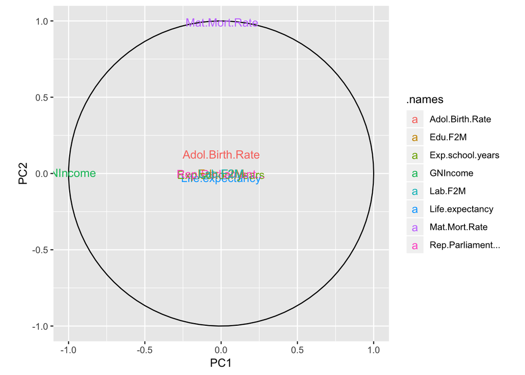

```r
# Plot each variables coefficients inside a unit circle to get insight on a possible interpretation for PCs
theta <- seq(0,2*pi,length.out = 100)
circle <- data.frame(x = cos(theta), y = sin(theta))
p <- ggplot(circle,aes(x,y)) + geom_path()

loadings <- data.frame(pca_human$rotation,
                       .names = row.names(pca_human$rotation))
p + geom_text(data=loadings,
              mapping=aes(x = PC1, y = PC2, label = .names, colour = .names)) +
  coord_fixed(ratio=1) +
  labs(x = "PC1", y = "PC2")
```

### Second PCA with standardized dataset

```r
pca_human_std
```

```
## Standard deviations (1, .., p=8):
## [1] 2.0708380 1.1397204 0.8750485 0.7788630 0.6619563 0.5363061 0.4589994
## [8] 0.3222406
##
## Rotation (n x k) = (8 x 8):
##                           PC1         PC2         PC3         PC4
## Life.expectancy   -0.44372240  0.02530473 -0.10991305  0.05834819
## Exp.school.years  -0.42766720 -0.13940571  0.07340270  0.07020294
## GNIncome          -0.35048295 -0.05060876  0.20168779  0.72727675
## Mat.Mort.Rate      0.43697098 -0.14508727  0.12522539  0.25170614
## Adol.Birth.Rate    0.41126010 -0.07708468 -0.01968243 -0.04986763
## Rep.Parliament... -0.08438558 -0.65136866 -0.72506309 -0.01396293
## Edu.F2M           -0.35664370 -0.03796058  0.24223089 -0.62678110
## Lab.F2M            0.05457785 -0.72432726  0.58428770 -0.06199424
##                          PC5         PC6         PC7         PC8
## Life.expectancy   -0.1628935  0.42242796 -0.43406432 -0.62737008
## Exp.school.years  -0.1659678  0.38606919  0.77962966  0.05415984
## GNIncome           0.4950306 -0.11120305 -0.13711838  0.16961173
## Mat.Mort.Rate      0.1800657 -0.17370039  0.35380306 -0.72193946
## Adol.Birth.Rate    0.4672068  0.76056557 -0.06897064  0.14335186
## Rep.Parliament...  0.1523699 -0.13749772  0.00568387  0.02306476
## Edu.F2M            0.5983585 -0.17713316  0.05773644 -0.16459453
## Lab.F2M           -0.2625067  0.03500707 -0.22729927  0.07304568
```

```r
summary(pca_human_std)
```

```
## Importance of components:
##                           PC1    PC2     PC3     PC4     PC5     PC6
## Standard deviation     2.0708 1.1397 0.87505 0.77886 0.66196 0.53631
## Proportion of Variance 0.5361 0.1624 0.09571 0.07583 0.05477 0.03595
## Cumulative Proportion  0.5361 0.6984 0.79413 0.86996 0.92473 0.96069
##                            PC7     PC8
## Standard deviation     0.45900 0.32224
## Proportion of Variance 0.02634 0.01298
## Cumulative Proportion  0.98702 1.00000
```

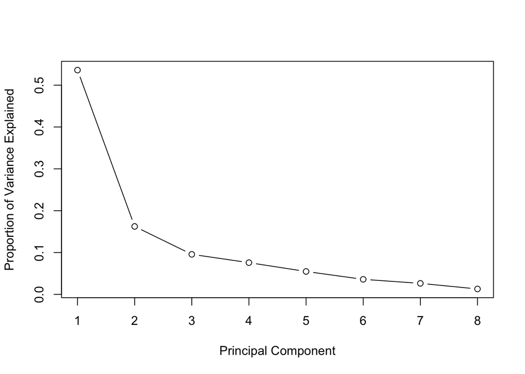

```r
# Compute standard deviation of each principal component
std_dev <- pca_human_std$sdev

# Compute variance
pr_var <- std_dev^2

# Proportion of variance explained
prop_varex <- pr_var/sum(pr_var)

# Scree plot
plot(prop_varex, xlab = "Principal Component",
             ylab = "Proportion of Variance Explained",
             type = "b")
```

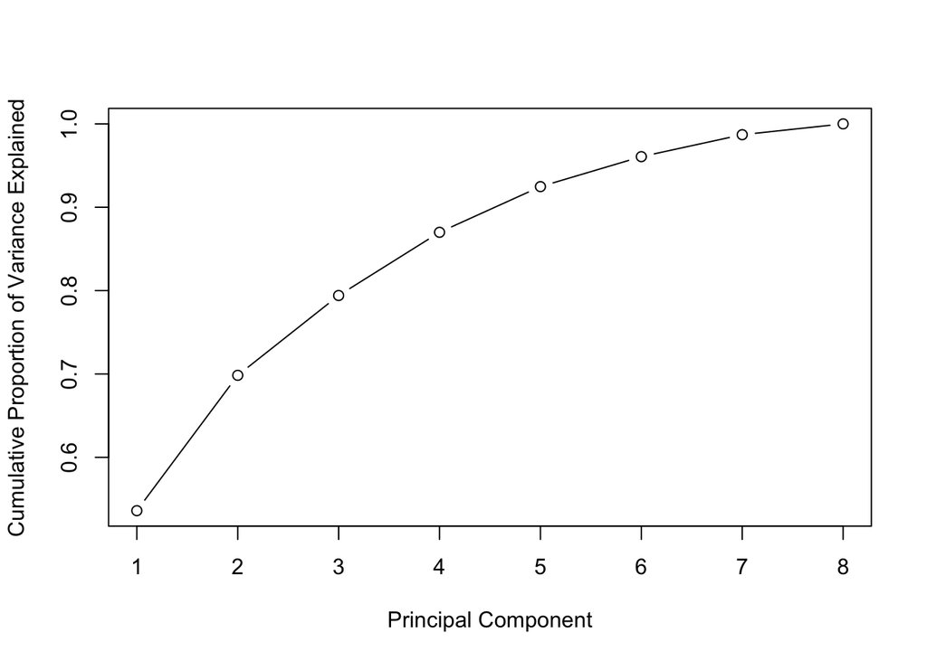

```r
# Cumulative scree plot
plot(cumsum(prop_varex), xlab = "Principal Component",
              ylab = "Cumulative Proportion of Variance Explained",
              type = "b")
```

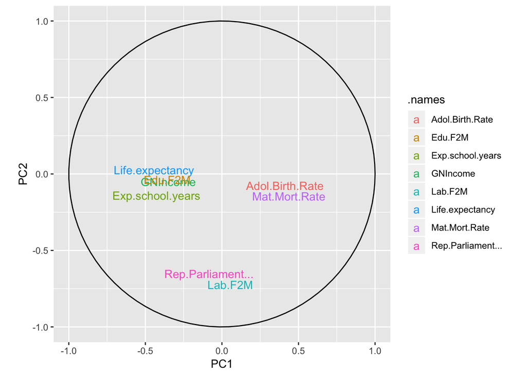

```r
# Plot each variables coefficients inside a unit circle to get insight on a possible interpretation for PCs
theta <- seq(0,2*pi,length.out = 100)
circle <- data.frame(x = cos(theta), y = sin(theta))
p <- ggplot(circle,aes(x,y)) + geom_path()

loadings <- data.frame(pca_human_std$rotation,
                       .names = row.names(pca_human_std$rotation))
p + geom_text(data=loadings,
              mapping=aes(x = PC1, y = PC2, label = .names, colour = .names)) +
  coord_fixed(ratio=1) +
  labs(x = "PC1", y = "PC2")
```

#### The goal of PCA is to explain most of the variability in the data with a smaller number of variables than the original data set. Now, for a large data set with “n” variables, we could examine pairwise plots of each variable as we did above against every other variable, but even for moderate “n”, the number of these plots becomes excessive and not useful.

#### In particular, we would like to find a low-dimensional representation of the data that captures as much of the information as possible.

#### This is what PCA allows us to do, as it finds a low-dimensional representation of a data set that contains as much of the variation as possible.

#### As we see above that the main difference in both PCA’s were, whether we had scaled the dataset or not, and the result was reflected in the principal components explaining the variance present. In the first PCA, all the variance is explained by first component which is quite incorrect, and we can clearly see the effect of variable skewness/kurtosis/distribution on the PC’s.

#### However, in the second PCA with standardized dataset, with the variability of each variable fixed such that their sd = 1, we can see the truer picture with different PC’s explaining different components of the dataset

#### As we see here, we can see a miinimum of 3 most relevant principal components. PC1 captures 53.6% of variation, PC2 16.2% and both PCs together capture almost 70% of variation.

#### The 1st PC seems to be about maternal mortality rate and adolescent birth rate. Both are highly associated variables! In the context of countries with low per capita income or GDP, both variables are quite heavily intertwined. This association or clustering (in the language of PCA’s) is clearly a function of a number of factors, including the greater risk inherent in pregnancy and delivery owing to lack of adequate medical care, greater prevalence of infectious diseases, which are cofactors in some deaths and the higher incidence of pregnancy.

#### The 2nd PC seems to be about women mobility which is reflected by ratio of women to men in the work force and women representation in parliament.

## Multiple Correspondence Analysis (MCA)

### Tea data from FactoMineR

```r
data(tea)
```

### Tea and variable distributions/summary

```r
# Select few variables
keep <- c("Tea", "frequency", "sex", "How", "relaxing", "effect.on.health")
tea_select <- dplyr::select(tea, one_of(keep))

# Summary of the subsetted data
glimpse(tea_select)
```

```
## Observations: 300
## Variables: 6
## $ Tea              <fct> black, black, Earl Grey, Earl Grey, Earl Grey...
## $ frequency        <fct> 1/day, 1/day, +2/day, 1/day, +2/day, 1/day, 3...
## $ sex              <fct> M, F, F, M, M, M, M, F, M, M, M, M, M, M, M, ...
## $ How              <fct> alone, milk, alone, alone, alone, alone, alon...
## $ relaxing         <fct> No.relaxing, No.relaxing, relaxing, relaxing,...
## $ effect.on.health <fct> No.effect on health, No.effect on health, No....
```

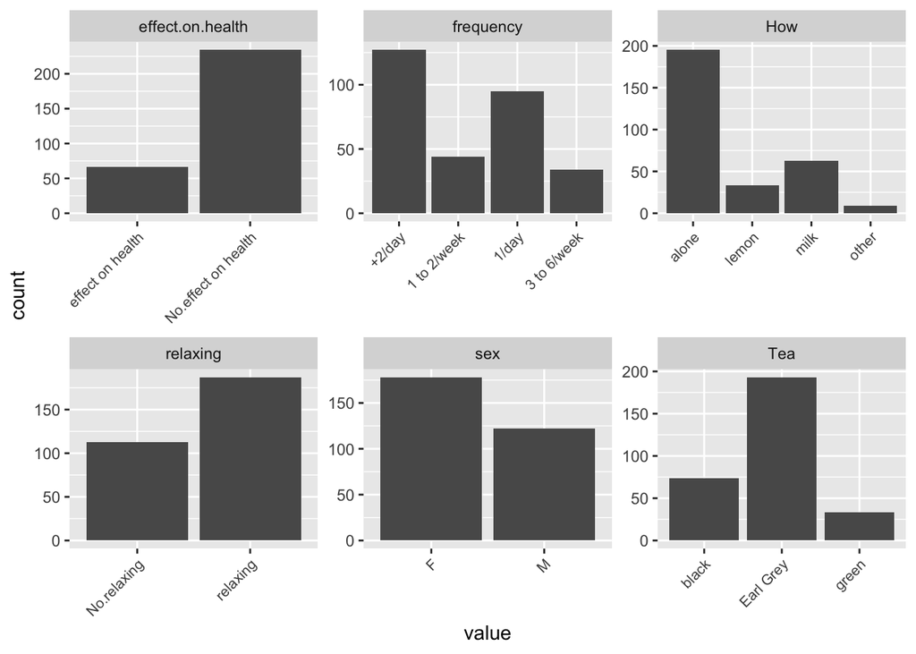

```r
# Visualise distributions of the variables
gather(tea_select) %>%
  ggplot(aes(value)) +
  facet_wrap("key", scales = "free") +
  theme(axis.text.x = element_text(angle = 45, hjust = 1, size = 8)) +
  geom_bar()
```

What we see here is that Early Grey is the most consumed kind of Tea,majoriy responding Tea as relaxing however, no effect on health is seen on many, with majority of females amongst the responders and many responders have it alone at a high frequency of +2/day.

### MCA

```r
tea_mca <- MCA(tea_select, graph = FALSE)

# Summary of MCA
summary(tea_mca)
```

```
##
## Call:
## MCA(X = tea_select, graph = FALSE)
##
##
## Eigenvalues
##                        Dim.1   Dim.2   Dim.3   Dim.4   Dim.5   Dim.6
## Variance               0.227   0.213   0.187   0.185   0.182   0.174
## % of var.             12.387  11.631  10.218  10.080   9.908   9.468
## Cumulative % of var.  12.387  24.018  34.236  44.316  54.225  63.692
##                        Dim.7   Dim.8   Dim.9  Dim.10  Dim.11
## Variance               0.152   0.148   0.130   0.119   0.116
## % of var.              8.267   8.098   7.092   6.513   6.338
## Cumulative % of var.  71.959  80.057  87.149  93.662 100.000
##
## Individuals (the 10 first)
##                Dim.1    ctr   cos2    Dim.2    ctr   cos2    Dim.3    ctr
## 1           |  0.438  0.282  0.126 |  0.224  0.078  0.033 | -0.423  0.318
## 2           |  0.328  0.158  0.056 |  0.282  0.125  0.041 | -0.767  1.046
## 3           | -0.636  0.594  0.603 | -0.342  0.183  0.174 |  0.064  0.007
## 4           |  0.211  0.065  0.048 | -0.085  0.011  0.008 | -0.086  0.013
## 5           | -0.304  0.136  0.115 | -0.019  0.001  0.000 |  0.039  0.003
## 6           |  0.211  0.065  0.048 | -0.085  0.011  0.008 | -0.086  0.013
## 7           |  0.072  0.008  0.003 | -0.197  0.061  0.021 |  0.534  0.508
## 8           | -0.178  0.046  0.013 |  0.854  1.139  0.308 |  0.068  0.008
## 9           | -0.082  0.010  0.005 |  0.362  0.205  0.098 | -0.330  0.194
## 10          | -0.444  0.289  0.162 |  0.500  0.391  0.206 | -0.172  0.053
##               cos2
## 1            0.117 |
## 2            0.304 |
## 3            0.006 |
## 4            0.008 |
## 5            0.002 |
## 6            0.008 |
## 7            0.152 |
## 8            0.002 |
## 9            0.082 |
## 10           0.024 |
##
## Categories (the 10 first)
```

[output cut: 16 more lines]

```
## 1 to 2/week   5.814 |   1.250  20.375   0.268   8.958 |
## +2/day       -0.093 |  -0.266   2.665   0.052  -3.941 |
## 3 to 6/week  -3.089 |   1.021  10.516   0.133   6.313 |
## F            -7.598 |   0.027   0.037   0.001   0.557 |
## M             7.598 |  -0.039   0.055   0.001  -0.557 |
## alone        -6.926 |   0.158   1.436   0.046   3.714 |
##
## Categorical variables (eta2)
##                    Dim.1 Dim.2 Dim.3
## Tea              | 0.086 0.430 0.236 |
## frequency        | 0.430 0.136 0.487 |
## sex              | 0.217 0.193 0.001 |
## How              | 0.201 0.310 0.262 |
## relaxing         | 0.259 0.080 0.025 |
## effect.on.health | 0.169 0.130 0.113 |
```

```r
# Description on the dimension of MCA:
dimdesc(tea_mca)
```

```
## $`Dim 1`
## $`Dim 1`$quali
##                          R2      p.value
## frequency        0.43035283 6.126221e-36
## relaxing         0.25926867 3.411902e-21
## sex              0.21740720 1.341552e-17
## How              0.20055142 2.561497e-14
## effect.on.health 0.16915112 1.127903e-13
## Tea              0.08585463 1.624676e-06
##
## $`Dim 1`$category
##                        Estimate      p.value
## No.relaxing          0.25038745 3.411902e-21
## 1/day                0.26975535 7.022606e-20
## M                    0.22617501 1.341552e-17
## effect on health     0.23656752 1.127903e-13
## milk                 0.43694935 1.152059e-06
## green                0.27131834 2.810580e-05
## 1 to 2/week          0.08083804 1.790922e-02
## alone                0.13398295 1.876177e-02
## 3 to 6/week          0.08083749 4.143368e-02
## black               -0.23108131 1.910251e-04
## other               -0.81706844 4.433926e-11
## No.effect on health -0.23656752 1.127903e-13
## F                   -0.22617501 1.341552e-17
## relaxing            -0.25038745 3.411902e-21
## +2/day              -0.43143088 8.756742e-36
##
##
## $`Dim 2`
## $`Dim 2`$quali
##                          R2      p.value
## Tea              0.43049300 4.915996e-37
## How              0.30966049 1.171181e-23
## sex              0.19305357 1.366580e-15
## effect.on.health 0.13023599 1.171471e-10
## frequency        0.13603174 2.070879e-09
## relaxing         0.07990218 6.443703e-07
##
## $`Dim 2`$category
```

[output cut: 29 more lines]

```
## 1 to 2/week          0.38761770 5.303215e-22
## Earl Grey            0.29800933 2.621465e-13
## 3 to 6/week          0.28878032 6.837716e-11
## effect on health     0.17523761 2.535985e-09
## lemon                0.45654646 7.757408e-08
## alone                0.15038168 1.782129e-04
## relaxing             0.07113249 5.696963e-03
## black                0.06115032 1.499559e-02
## No.relaxing         -0.07113249 5.696963e-03
## other               -0.34255089 2.707970e-03
## +2/day              -0.26836999 6.790217e-05
## No.effect on health -0.17523761 2.535985e-09
## 1/day               -0.40802803 5.332058e-13
## milk                -0.26437725 8.963243e-14
## green               -0.35915965 9.118354e-15
```

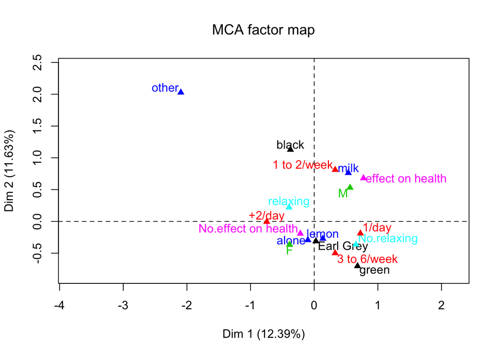

```r
# Plotting MCA
plot(tea_mca, invisible=c("ind"), habillage = "quali")
```

#### To begin with we see that around 24% of variance is captured by the two dimensions plotted here.

#### We can see that people who have earl grey tea might have it with lemon and may have it around 1/day but also suggest as Not relaxing. Also, females may have tea alone, at a frequency of +2/day to 3 to 6/week, but may not report effect on health. Whereas, males may have tea with milk and may report a +ve effect on health on consuming it 1 to 2/week.